# AIC Analysis Q2

Elizabeth Max

#Set up

```r
rm(list=ls())

#AIC
library(AICcmodavg)
library(plm) #for random factors
library(lme4)
library(car)

#Table
library(sjPlot)
library(sjmisc)
library(sjlabelled)
library(insight)
library(tibble)


#extra, just in case
library(tidyverse)
library(ggpubr)
library(scales)
library(chron)
library(plotly)
library(aweek)
library(easypackages)
library(renv)
library(here)
library(ggthemes)
library(gridExtra)
library(patchwork)
library(tidyquant)
library(recipes)
library(cranlogs)
library(knitr)
library(openair)
library(xts)
library(dplyr)
library(reshape2)
```

Set work drive and upload csv

```r
#Set work drive
setwd("C:/Users/Elizabeth Max/iCloudDrive/Thesis/Data/R")
#upload file
masterfile <- read.csv("masterfile_aic.csv")
```

#All unique combinations for environmental indicies

```r
##Get all unique combinations of NPGO, PDO, SOI, CUTI, and BEUTI at one month lag.
#Can use these lists for 3 month lag too.
#First create the list of variables
lag1.indicies <- c("NPGO.1", "PDO.1", "SOI.1", "CUTI_37.1", "BEUTI_37.1")
##Now get all unique combinations
#all values (5)
combn(unique(lag1.indicies), 5)
```

```
##      [,1]
## [1,] "NPGO.1"
## [2,] "PDO.1"
## [3,] "SOI.1"
## [4,] "CUTI_37.1"
## [5,] "BEUTI_37.1"
```

```r
#4 values per list
combn(unique(lag1.indicies), 4)
```

```
##      [,1]        [,2]         [,3]         [,4]         [,5]
## [1,] "NPGO.1"    "NPGO.1"     "NPGO.1"     "NPGO.1"     "PDO.1"
## [2,] "PDO.1"     "PDO.1"      "PDO.1"      "SOI.1"      "SOI.1"
## [3,] "SOI.1"     "SOI.1"      "CUTI_37.1"  "CUTI_37.1"  "CUTI_37.1"
## [4,] "CUTI_37.1" "BEUTI_37.1" "BEUTI_37.1" "BEUTI_37.1" "BEUTI_37.1"
```

```r
#3 values per list
combn(unique(lag1.indicies), 3)
```

```
##      [,1]     [,2]        [,3]         [,4]        [,5]         [,6]
## [1,] "NPGO.1" "NPGO.1"    "NPGO.1"     "NPGO.1"    "NPGO.1"     "NPGO.1"
## [2,] "PDO.1"  "PDO.1"     "PDO.1"      "SOI.1"     "SOI.1"      "CUTI_37.1"
## [3,] "SOI.1"  "CUTI_37.1" "BEUTI_37.1" "CUTI_37.1" "BEUTI_37.1" "BEUTI_37.1"
##      [,7]        [,8]         [,9]         [,10]
## [1,] "PDO.1"     "PDO.1"      "PDO.1"      "SOI.1"
## [2,] "SOI.1"     "SOI.1"      "CUTI_37.1"  "CUTI_37.1"
## [3,] "CUTI_37.1" "BEUTI_37.1" "BEUTI_37.1" "BEUTI_37.1"
```

```r
#2 values per list
combn(unique(lag1.indicies), 2)
```

```
##      [,1]     [,2]     [,3]        [,4]         [,5]    [,6]
## [1,] "NPGO.1" "NPGO.1" "NPGO.1"    "NPGO.1"     "PDO.1" "PDO.1"
## [2,] "PDO.1"  "SOI.1"  "CUTI_37.1" "BEUTI_37.1" "SOI.1" "CUTI_37.1"
##      [,7]         [,8]        [,9]         [,10]
## [1,] "PDO.1"      "SOI.1"     "SOI.1"      "CUTI_37.1"
## [2,] "BEUTI_37.1" "CUTI_37.1" "BEUTI_37.1" "BEUTI_37.1"
```

```r
#1 value per list
combn(unique(lag1.indicies), 1)
```

```
##      [,1]     [,2]    [,3]    [,4]        [,5]
## [1,] "NPGO.1" "PDO.1" "SOI.1" "CUTI_37.1" "BEUTI_37.1"
```

#AIC - Q2, all upright, one month lag This is to answer my second question climate patterns on cover. 2) Does cover respond to ocean climate patterns (NPGO, PDO, SOI, CUTI, BEUTI)?

Save AIC results as a CSV

```r
write.csv(uindmodel1_aic, "C:/Users/Elizabeth Max/iCloudDrive/Thesis/Data/R/uindmodel1_aic.csv", row.names = TRUE)
```

Make a nice table of Upright model AIC rank results

```r
uindmodel1_table <-
  tab_df(uindmodel1_aic,  #models to table
         alternate.rows = TRUE,
         title = "AIC Model Ranking Results - all upright species. Climate indices lagged 1 month.",
         col.header = c( #Default headers are okay, these are better
            "Model",
            "K",
            "AIC",
            "Delta AIC",
            "AIC Wt",
            "Cum. Wt",
            "LL"
            ),
         CSS = list( #Use CSS to modify table appearance
           css.footnote = 'text-align: left; '
         ),
         footnote = "<i>K</i> = multiplier penalty term depending on the number of terms in the model.<br/>
          <i>AIC</i> = Aikaki Information Criterion (AIC); models with lower AIC values contain more information.<br/>
         <i>Delta AIC</i> = Change in AIC value from top ranked model.<br/>
         <i>AIC Wt</i> = weight of evidence for given model.</br>
         <i>Cum.Wt</i> = cumulative AIC weight.</br>
         <i>LL</i> = log-likelihood of given model.",
         show.footnote = TRUE)

print(uindmodel1_table)
```

Model uind4.4.1 is ranked the highest. uind4.4.1 <- lm(upright ~ NPGO.1 + SOI.1 + CUTI_37.1 + BEUTI_37.1, data = masterfile) Let’s take a closer look.

Fitting and analyzing the top ranked model

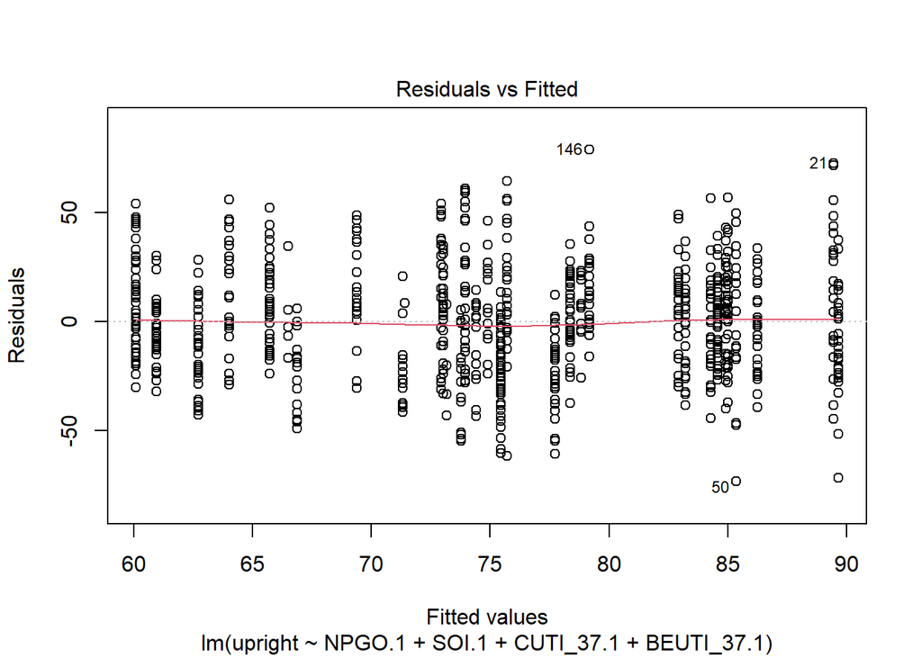

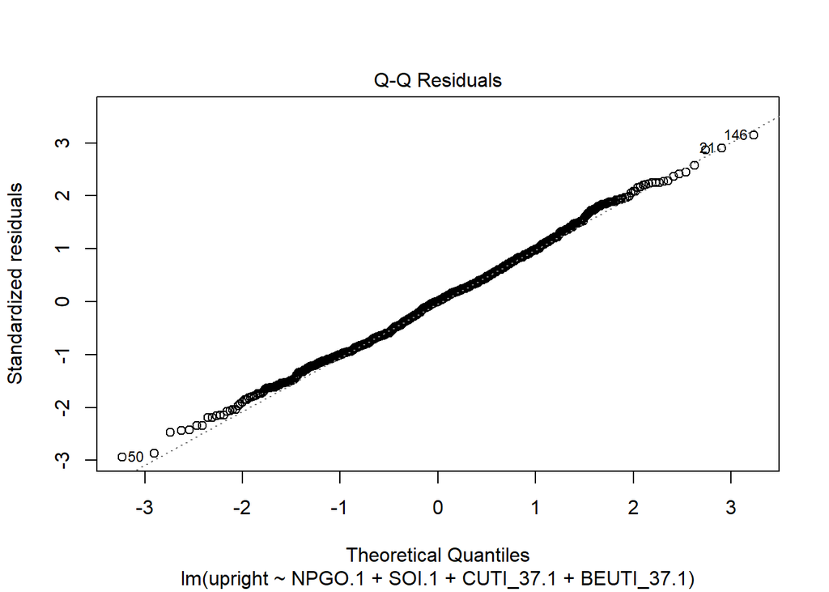

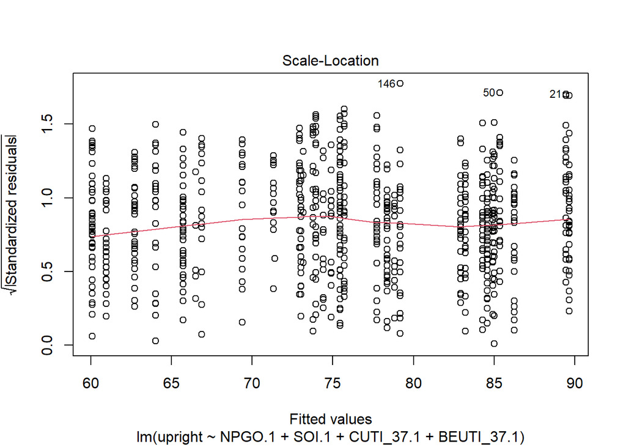

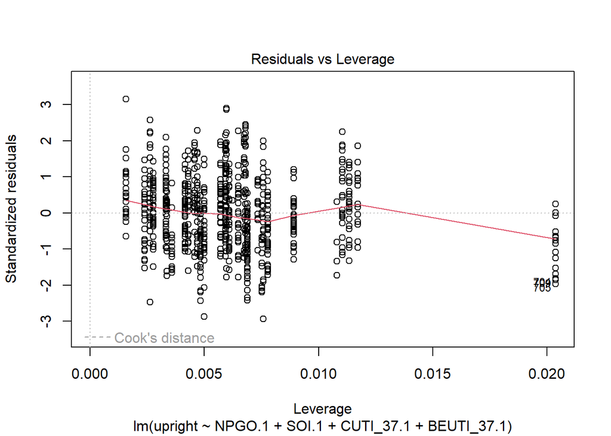

```r
plot(uind4.4.1)
```

```r
uind4.4.1
```

```
##
## Call:
## lm(formula = upright ~ NPGO.1 + SOI.1 + CUTI_37.1 + BEUTI_37.1,
##     data = masterfile)
##
## Coefficients:
## (Intercept)       NPGO.1        SOI.1    CUTI_37.1   BEUTI_37.1
##     74.9828      -5.8016      -0.8223      -5.9444       1.6747
```

```r
summary(uind4.4.1)
```

```
##
## Call:
## lm(formula = upright ~ NPGO.1 + SOI.1 + CUTI_37.1 + BEUTI_37.1,
##     data = masterfile)
##
## Residuals:
##     Min      1Q  Median      3Q     Max
## -73.348 -18.156  -0.022  16.075  78.838
##
## Coefficients:
##             Estimate Std. Error t value Pr(>|t|)
## (Intercept)  74.9828     1.2510  59.936  < 2e-16 ***
## NPGO.1       -5.8016     0.6498  -8.928  < 2e-16 ***
## SOI.1        -0.8223     0.4783  -1.719  0.08598 .
## CUTI_37.1    -5.9444     4.8043  -1.237  0.21633
## BEUTI_37.1    1.6747     0.6290   2.662  0.00792 **
## ---
## Signif. codes:  0 '***' 0.001 '**' 0.01 '*' 0.05 '.' 0.1 ' ' 1
##
## Residual standard error: 25.04 on 806 degrees of freedom
## Multiple R-squared:  0.1126, Adjusted R-squared:  0.1082
## F-statistic: 25.56 on 4 and 806 DF,  p-value: < 2.2e-16
```

```r
anova(uind4.4.1)
```

```
## Analysis of Variance Table
##
## Response: upright
##             Df Sum Sq Mean Sq F value    Pr(>F)
## NPGO.1       1  56989   56989 90.9023 < 2.2e-16 ***
## SOI.1        1    226     226  0.3604  0.548435
## CUTI_37.1    1   2431    2431  3.8781  0.049263 *
## BEUTI_37.1   1   4444    4444  7.0880  0.007915 **
## Residuals  806 505303     627
## ---
## Signif. codes:  0 '***' 0.001 '**' 0.01 '*' 0.05 '.' 0.1 ' ' 1
```

```r
confint(uind4.4.1)
```

```
##                   2.5 %     97.5 %
## (Intercept)  72.5271232 77.4385200
## NPGO.1       -7.0771761 -4.5260332
## SOI.1        -1.7611926  0.1166191
## CUTI_37.1   -15.3748108  3.4859689
## BEUTI_37.1    0.4399622  2.9094895
```

uind4.4.1 <- lm(upright ~ NPGO.1 + SOI.1 + CUTI_37.1 + BEUTI_37.1, data = masterfile) Table of model uind4.4.1 with standard error

```
## `ci_method` must be one of "residual", "wald", "normal", "profile",
##   "boot", "uniroot", "betwithin" or "ml1". Using "wald" now.
```

#AIC - Q2, all upright, three month lag This is to answer my second question climate patterns on cover. 2) Does cover respond to ocean climate patterns (NPGO, PDO, SOI, CUTI, BEUTI)?

Save AICc results as a CSV

```r
write.csv(uindmodel3_aic, "C:/Users/Elizabeth Max/iCloudDrive/Thesis/Data/R/uindmodel3_aic.csv", row.names = TRUE)
```

Make a nice table of Upright model AIC rank results

```r
uindmodel3_table <-
  tab_df(uindmodel3_aic,  #models to table
         alternate.rows = TRUE,
         title = "AIC Model Ranking Results - all upright species. Climate indices lagged 3 months.",
         show.footnote = TRUE)

print(uindmodel3_table)
```

Model uind5.1.3 is ranked the highest. uind5.1.3 <- lm(upright ~ NPGO.3 + PDO.3 + SOI.3 + CUTI_37.3 + BEUTI_37.3, data = masterfile) Let’s take a closer look.

Fitting and analyzing the top ranked model

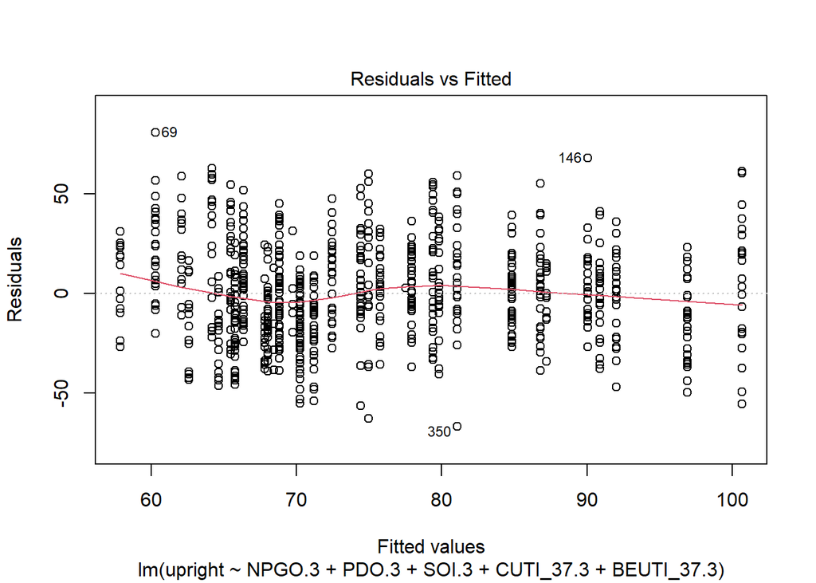

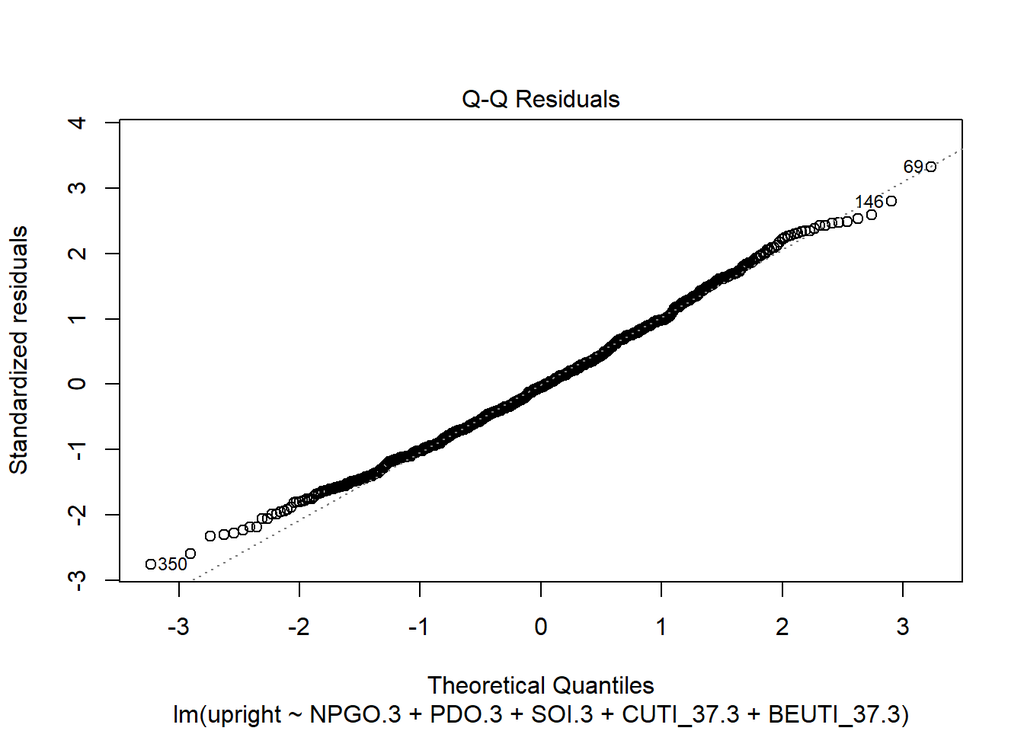

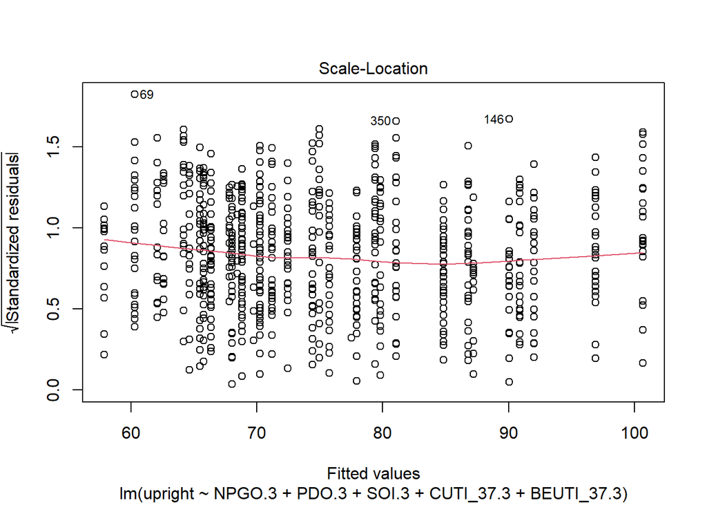

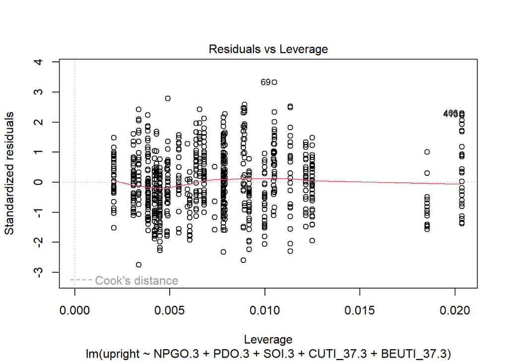

```r
plot(uind5.1.3)
```

```r
uind5.1.3
```

```
##
## Call:
## lm(formula = upright ~ NPGO.3 + PDO.3 + SOI.3 + CUTI_37.3 + BEUTI_37.3,
##     data = masterfile)
##
## Coefficients:
## (Intercept)       NPGO.3        PDO.3        SOI.3    CUTI_37.3   BEUTI_37.3
##      86.101       -5.051        5.434        2.428      -34.504        1.662
```

```r
summary(uind5.1.3)
```

```
##
## Call:
## lm(formula = upright ~ NPGO.3 + PDO.3 + SOI.3 + CUTI_37.3 + BEUTI_37.3,
##     data = masterfile)
##
## Residuals:
##     Min      1Q  Median      3Q     Max
## -67.059 -17.114  -1.034  16.800  80.701
##
## Coefficients:
##             Estimate Std. Error t value Pr(>|t|)
## (Intercept)  86.1011     2.2089  38.979  < 2e-16 ***
## NPGO.3       -5.0510     0.8389  -6.021 2.63e-09 ***
## PDO.3         5.4335     0.8298   6.548 1.04e-10 ***
## SOI.3         2.4280     0.6368   3.813 0.000148 ***
## CUTI_37.3   -34.5042     5.2559  -6.565 9.33e-11 ***
## BEUTI_37.3    1.6616     0.2651   6.267 6.00e-10 ***
## ---
## Signif. codes:  0 '***' 0.001 '**' 0.01 '*' 0.05 '.' 0.1 ' ' 1
##
## Residual standard error: 24.39 on 805 degrees of freedom
## Multiple R-squared:  0.159,  Adjusted R-squared:  0.1538
## F-statistic: 30.44 on 5 and 805 DF,  p-value: < 2.2e-16
```

```r
anova(uind5.1.3)
```

```
## Analysis of Variance Table
##
## Response: upright
##             Df Sum Sq Mean Sq F value    Pr(>F)
## NPGO.3       1  38966   38966 65.5039 2.135e-15 ***
## PDO.3        1  13826   13826 23.2428 1.707e-06 ***
## SOI.3        1   9951    9951 16.7280 4.748e-05 ***
## CUTI_37.3    1   4428    4428  7.4431  0.006507 **
## BEUTI_37.3   1  23362   23362 39.2728 6.001e-10 ***
## Residuals  805 478861     595
## ---
## Signif. codes:  0 '***' 0.001 '**' 0.01 '*' 0.05 '.' 0.1 ' ' 1
```

```r
confint(uind5.1.3)
```

```
##                  2.5 %     97.5 %
## (Intercept)  81.765193  90.437093
## NPGO.3       -6.697667  -3.404342
## PDO.3         3.804712   7.062346
## SOI.3         1.177964   3.678057
## CUTI_37.3   -44.821057 -24.187248
## BEUTI_37.3    1.141134   2.182030
```

Table of model uind5.1.3 with standard error

```
## `ci_method` must be one of "residual", "wald", "normal", "profile",
##   "boot", "uniroot", "betwithin" or "ml1". Using "wald" now.
```

```
## Length of `pred.labels` does not equal number of predictors, no labelling applied.
```

#AIC - Q2, upright algae, one month lag This is to answer my second question climate patterns on cover. 2) Does cover respond to ocean climate patterns (NPGO, PDO, SOI, CUTI, BEUTI)?

Save AIC results as a CSV

```r
write.csv(uaindmodel1_aic, "C:/Users/Elizabeth Max/iCloudDrive/Thesis/Data/R/uaindmodel1_aic.csv", row.names = TRUE)
```

Make a nice table of upalgae model AIC rank results

```r
uaindmodel1_table <-
  tab_df(uaindmodel1_aic,  #models to table
         alternate.rows = TRUE,
         title = "AIC Model Ranking Results - Upright (non-crustose) algae species. Climate indices lagged 1 month.",
         col.header = c( #Default headers are okay, these are better
            "Model",
            "K",
            "AIC",
            "Delta AIC",
            "AIC Wt",
            "Cum. Wt",
            "LL"),
            CSS = list( #Use CSS to modify table appearance
           css.footnote = 'text-align: left; ',
         footnote = "<i>K</i> = multiplier penalty term depending on the number of terms in the model.<br/>
          <i>AIC</i> = Aikaki Information Criterion (AIC); models with lower AIC values contain more information.<br/>
         <i>Delta AIC</i> = Change in AIC value from top ranked model.<br/>
         <i>AIC Wt</i> = weight of evidence for given model.</br>
         <i>Cum.Wt</i> = cumulative AIC weight.</br>
         <i>LL</i> = log-likelihood of given model."),
         show.footnote = TRUE)

print(uaindmodel1_table)
```

Model uaind4.3.1 is ranked the highest. uaind4.3.1 <- lm(upalgae ~ NPGO.1 + PDO.1 + CUTI_37.1 + BEUTI_37.1, data = masterfile) Let’s take a closer look.

Fitting and analyzing the top ranked model

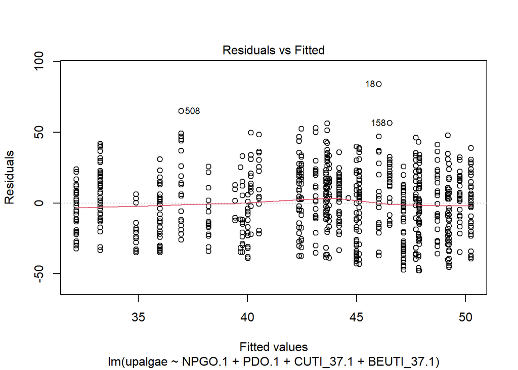

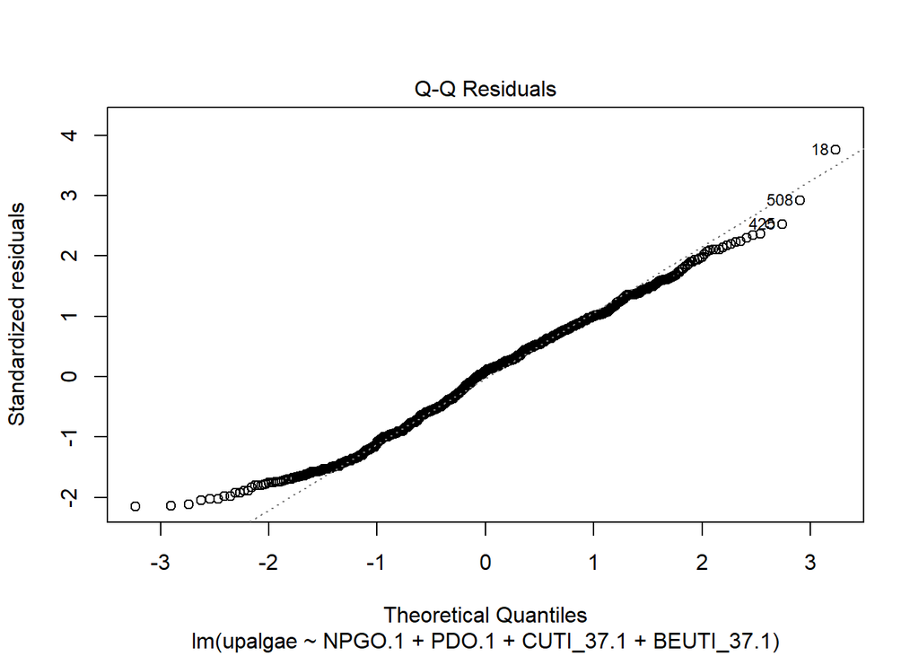

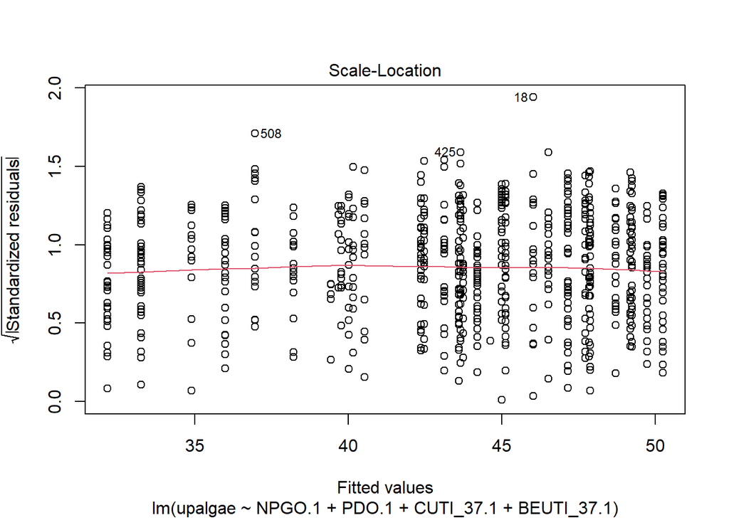

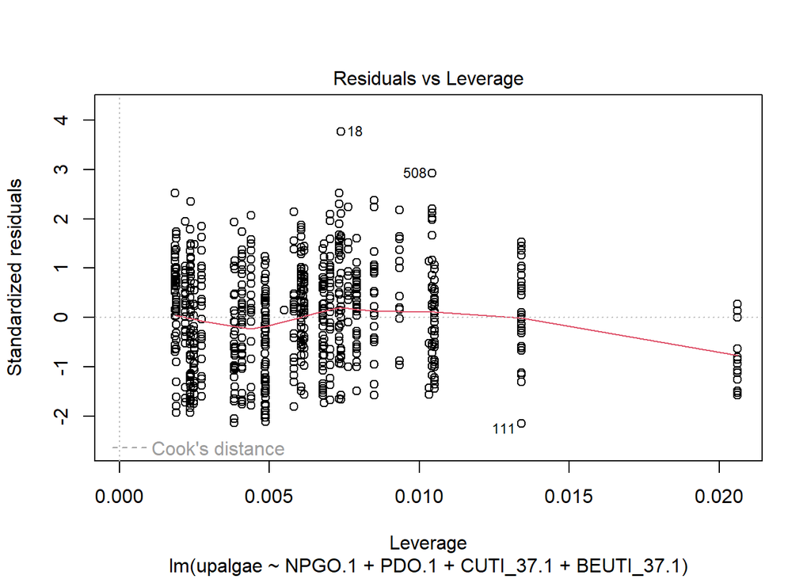

```r
plot(uaind4.3.1)
```

```r
uaind4.3.1
```

```
##
## Call:
## lm(formula = upalgae ~ NPGO.1 + PDO.1 + CUTI_37.1 + BEUTI_37.1,
##     data = masterfile)
##
## Coefficients:
## (Intercept)       NPGO.1        PDO.1    CUTI_37.1   BEUTI_37.1
##      45.326       -3.912       -2.290      -10.123        1.125
```

```r
summary(uaind4.3.1)
```

```
##
## Call:
## lm(formula = upalgae ~ NPGO.1 + PDO.1 + CUTI_37.1 + BEUTI_37.1,
##     data = masterfile)
##
## Residuals:
##     Min      1Q  Median      3Q     Max
## -47.893 -17.029   2.007  15.874  83.971
##
## Coefficients:
##             Estimate Std. Error t value Pr(>|t|)
## (Intercept)  45.3261     1.1809  38.383  < 2e-16 ***
## NPGO.1       -3.9118     0.6008  -6.511 1.31e-10 ***
## PDO.1        -2.2900     0.7295  -3.139  0.00176 **
## CUTI_37.1   -10.1227     4.4330  -2.283  0.02266 *
## BEUTI_37.1    1.1254     0.5482   2.053  0.04039 *
## ---
## Signif. codes:  0 '***' 0.001 '**' 0.01 '*' 0.05 '.' 0.1 ' ' 1
##
## Residual standard error: 22.38 on 806 degrees of freedom
## Multiple R-squared:  0.05486,    Adjusted R-squared:  0.05017
## F-statistic:  11.7 on 4 and 806 DF,  p-value: 3.083e-09
```

```r
anova(uaind4.3.1)
```

```
## Analysis of Variance Table
##
## Response: upalgae
##             Df Sum Sq Mean Sq F value    Pr(>F)
## NPGO.1       1  17175 17175.3 34.2897 6.911e-09 ***
## PDO.1        1   3629  3629.3  7.2457  0.007255 **
## CUTI_37.1    1    517   517.0  1.0322  0.309936
## BEUTI_37.1   1   2111  2111.2  4.2149  0.040392 *
## Residuals  806 403716   500.9
## ---
## Signif. codes:  0 '***' 0.001 '**' 0.01 '*' 0.05 '.' 0.1 ' ' 1
```

```r
confint(uaind4.3.1)
```

```
##                   2.5 %     97.5 %
## (Intercept)  43.0081253 47.6441421
## NPGO.1       -5.0910790 -2.7325882
## PDO.1        -3.7219721 -0.8581068
## CUTI_37.1   -18.8243224 -1.4210556
## BEUTI_37.1    0.0494007  2.2013607
```

NPGO.1 + PDO.1 + CUTI_37.1 + BEUTI_37.1 Table of model uaind4.3.1 with standard error

```
## `ci_method` must be one of "residual", "wald", "normal", "profile",
##   "boot", "uniroot", "betwithin" or "ml1". Using "wald" now.
```

#AIC - Q2, upright algae, three month lag This is to answer my second question climate patterns on cover. 2) Does cover respond to ocean climate patterns (NPGO, PDO, SOI, CUTI, BEUTI)?

Save AICc results as a CSV

```r
write.csv(uaindmodel3_aic, "C:/Users/Elizabeth Max/iCloudDrive/Thesis/Data/R/uaindmodel3_aic.csv", row.names = TRUE)
```

Make a nice table of upalgae model AIC rank results

```r
uaindmodel3_table <-
  tab_df(uaindmodel3_aic,  #models to table
         alternate.rows = TRUE,
         title = "AIC Model Ranking Results - Upright (non-crustose) algae species. Climate indices lagged 3 months.",
         show.footnote = TRUE)

print(uaindmodel3_table)
```

Model uaind4.4.3 is ranked the highest. uaind4.4.3 <- lm(upalgae ~ NPGO.3 + SOI.3 + CUTI_37.3 + BEUTI_37.3, data = masterfile) Let’s take a closer look.

Fitting and analyzing the top ranked model

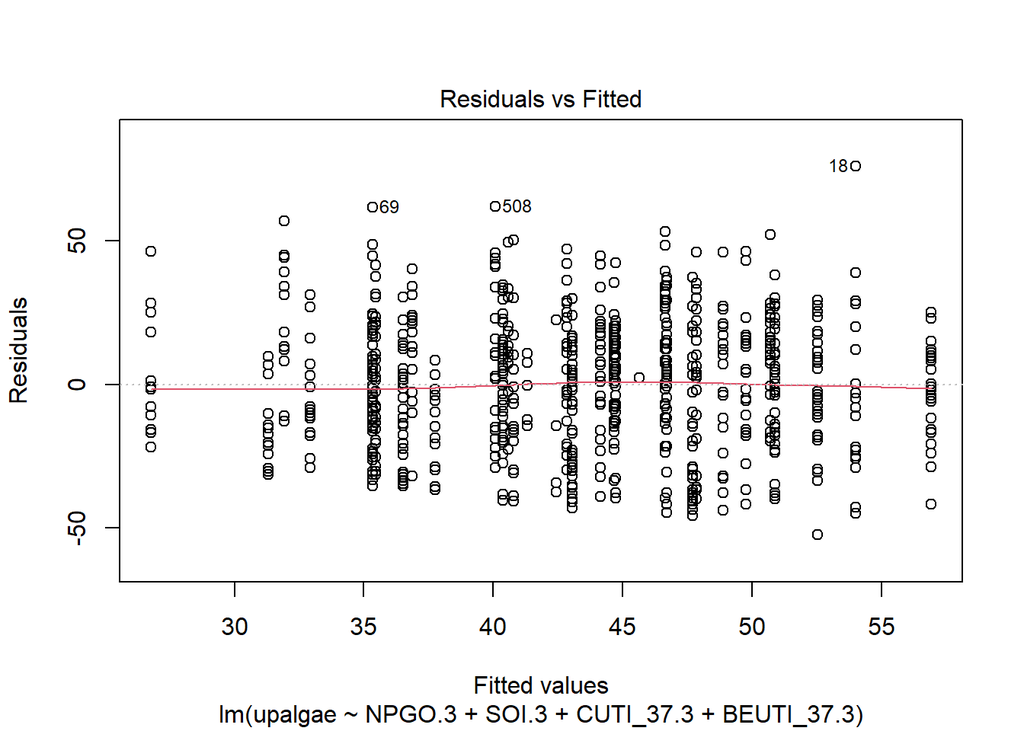

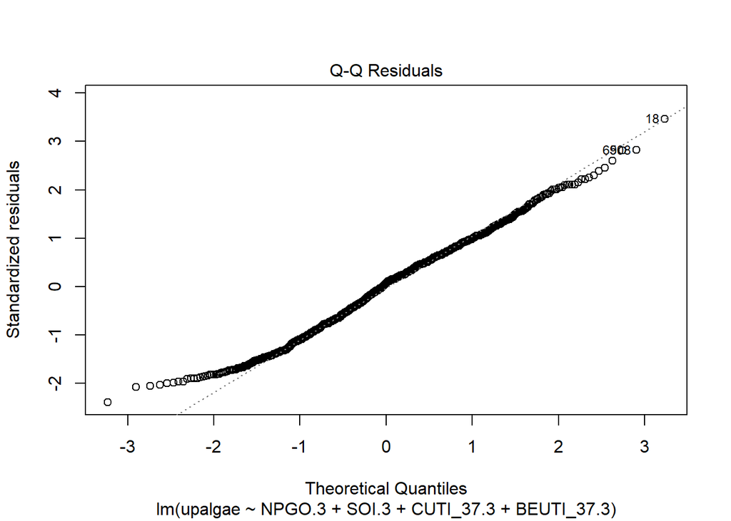

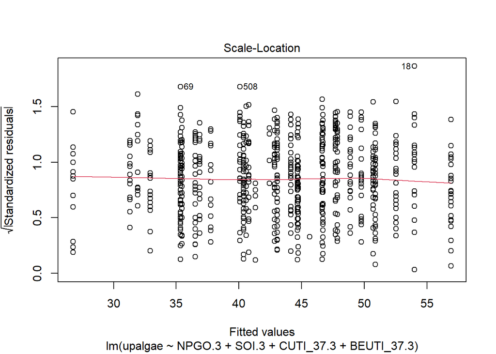

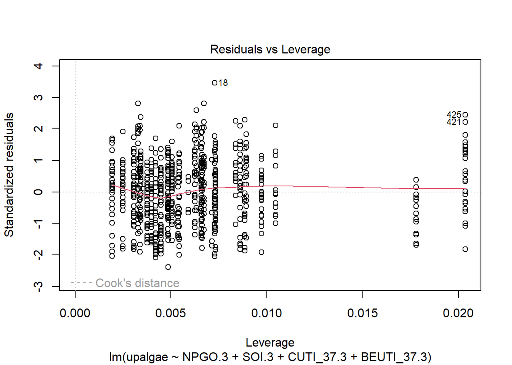

```r
plot(uaind4.4.3)
```

```r
uaind4.4.3
```

```
##
## Call:
## lm(formula = upalgae ~ NPGO.3 + SOI.3 + CUTI_37.3 + BEUTI_37.3,
##     data = masterfile)
##
## Coefficients:
## (Intercept)       NPGO.3        SOI.3    CUTI_37.3   BEUTI_37.3
##      51.348       -4.539        2.162      -24.665        1.143
```

```r
summary(uaind4.4.3)
```

```
##
## Call:
## lm(formula = upalgae ~ NPGO.3 + SOI.3 + CUTI_37.3 + BEUTI_37.3,
##     data = masterfile)
##
## Residuals:
##     Min      1Q  Median      3Q     Max
## -52.518 -16.682   1.483  15.272  76.024
##
## Coefficients:
##             Estimate Std. Error t value Pr(>|t|)
## (Intercept)  51.3480     1.9844  25.876  < 2e-16 ***
## NPGO.3       -4.5386     0.7353  -6.173 1.06e-09 ***
## SOI.3         2.1619     0.5496   3.934 9.08e-05 ***
## CUTI_37.3   -24.6652     4.7126  -5.234 2.12e-07 ***
## BEUTI_37.3    1.1427     0.2383   4.795 1.93e-06 ***
## ---
## Signif. codes:  0 '***' 0.001 '**' 0.01 '*' 0.05 '.' 0.1 ' ' 1
##
## Residual standard error: 22 on 806 degrees of freedom
## Multiple R-squared:  0.08665,    Adjusted R-squared:  0.08212
## F-statistic: 19.12 on 4 and 806 DF,  p-value: 4.922e-15
```

```r
anova(uaind4.4.3)
```

```
## Analysis of Variance Table
##
## Response: upalgae
##             Df Sum Sq Mean Sq F value    Pr(>F)
## NPGO.3       1  13282 13282.0 27.4400 2.070e-07 ***
## SOI.3        1   9758  9757.6 20.1587 8.167e-06 ***
## CUTI_37.3    1   2842  2841.6  5.8706   0.01562 *
## BEUTI_37.3   1  11131 11131.2 22.9964 1.933e-06 ***
## Residuals  806 390136   484.0
## ---
## Signif. codes:  0 '***' 0.001 '**' 0.01 '*' 0.05 '.' 0.1 ' ' 1
```

```r
confint(uaind4.4.3)
```

```
##                   2.5 %     97.5 %
## (Intercept)  47.4528669  55.243208
## NPGO.3       -5.9817896  -3.095316
## SOI.3         1.0831461   3.240663
## CUTI_37.3   -33.9156517 -15.414768
## BEUTI_37.3    0.6749492   1.610410
```

NPGO.3 + SOI.3 + CUTI_37.3 + BEUTI_37.3 Table of model uaind4.4.3 with standard error

```
## `ci_method` must be one of "residual", "wald", "normal", "profile",
##   "boot", "uniroot", "betwithin" or "ml1". Using "wald" now.
```

```
## Length of `pred.labels` does not equal number of predictors, no labelling applied.
```

#AIC - Q2, upright invertebrate, one month lag This is to answer my second question climate patterns on cover. 2) Does cover respond to ocean climate patterns (NPGO, PDO, SOI, CUTI, BEUTI)?

Save AICc results as a CSV

```r
write.csv(uiindmodel1_aic, "C:/Users/Elizabeth Max/iCloudDrive/Thesis/Data/R/uiindmodel1_aic.csv", row.names = TRUE)
```

Make a nice table of upinvert model AIC rank results

```r
uiindmodel1_table <-
  tab_df(uiindmodel1_aic,  #models to table
         alternate.rows = TRUE,
         title = "AIC Model Ranking Results - Upright (non-crustose) invertebrate species.",
         col.header = c( #Default headers are okay, these are better
            "Model",
            "K",
            "AIC",
            "Delta AIC",
            "AIC Wt",
            "Cum. Wt",
            "LL"),
            CSS = list( #Use CSS to modify table appearance
           css.footnote = 'text-align: left; ',
         footnote = "<i>K</i> = multiplier penalty term depending on the number of terms in the model.<br/>
          <i>AIC</i> = Aikaki Information Criterion (AIC); models with lower AIC values contain more information.<br/>
         <i>Delta AIC</i> = Change in AIC value from top ranked model.<br/>
         <i>AIC Wt</i> = weight of evidence for given model.</br>
         <i>Cum.Wt</i> = cumulative AIC weight.</br>
         <i>LL</i> = log-likelihood of given model."),
         show.footnote = TRUE)

print(uiindmodel1_table)
```

Model uiind1.3.1 is ranked the highest. uiind1.3.1 <- lm(upinverts ~ SOI.1, data = masterfile) Let’s take a closer look.

Fitting and analyzing the top ranked model

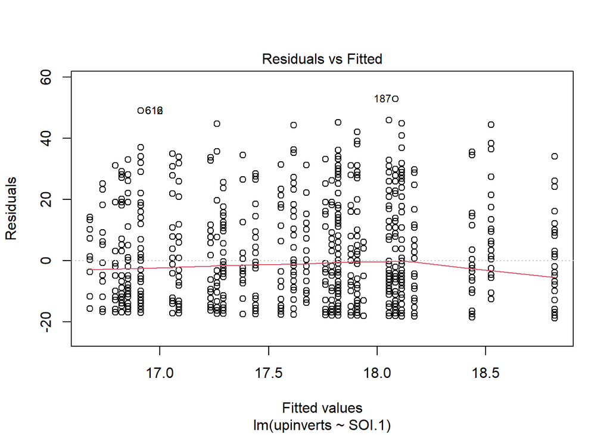

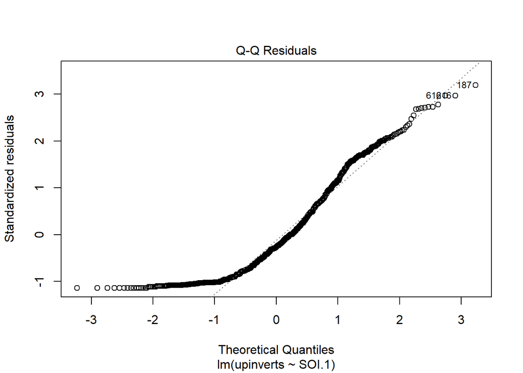

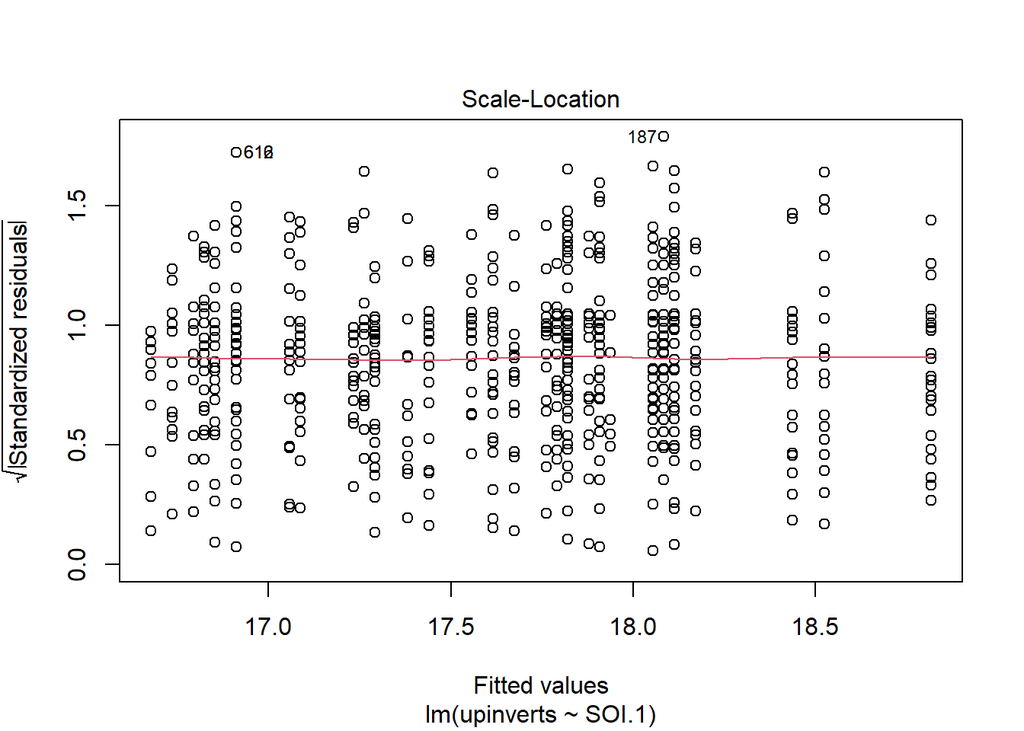

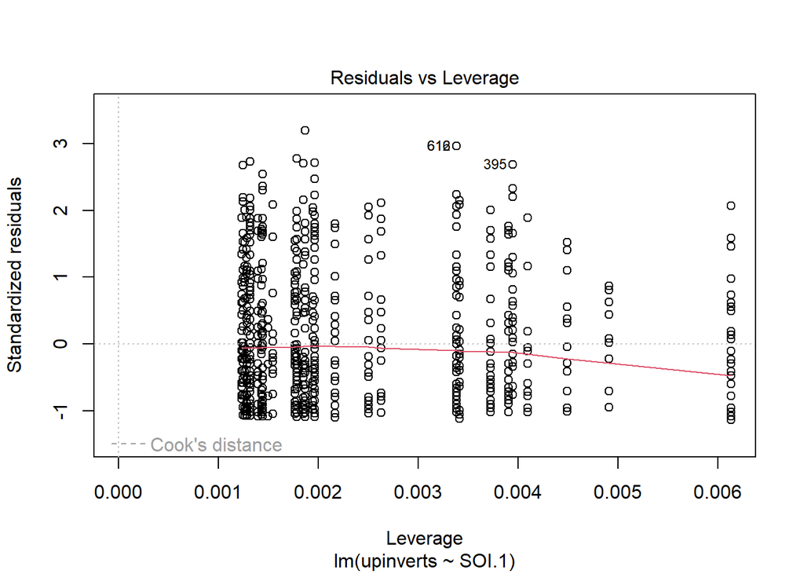

```r
plot(uiind1.3.1)
```

```r
uiind1.3.1
```

```
##
## Call:
## lm(formula = upinverts ~ SOI.1, data = masterfile)
##
## Coefficients:
## (Intercept)        SOI.1
##     17.5860       0.2932
```

```r
summary(uiind1.3.1)
```

```
##
## Call:
## lm(formula = upinverts ~ SOI.1, data = masterfile)
##
## Residuals:
##     Min      1Q  Median      3Q     Max
## -18.818 -14.821  -4.293  10.942  52.916
##
## Coefficients:
##             Estimate Std. Error t value Pr(>|t|)
## (Intercept)  17.5860     0.5882  29.900   <2e-16 ***
## SOI.1         0.2932     0.2965   0.989    0.323
## ---
## Signif. codes:  0 '***' 0.001 '**' 0.01 '*' 0.05 '.' 0.1 ' ' 1
##
## Residual standard error: 16.57 on 809 degrees of freedom
## Multiple R-squared:  0.001208,   Adjusted R-squared:  -2.674e-05
## F-statistic: 0.9783 on 1 and 809 DF,  p-value: 0.3229
```

```r
anova(uiind1.3.1)
```

```
## Analysis of Variance Table
##
## Response: upinverts
##            Df Sum Sq Mean Sq F value Pr(>F)
## SOI.1       1    269  268.65  0.9783 0.3229
## Residuals 809 222146  274.59
```

```r
confint(uiind1.3.1)
```

```
##                  2.5 %     97.5 %
## (Intercept) 16.4314357 18.7404661
## SOI.1       -0.2886963  0.8751739
```

```
## `ci_method` must be one of "residual", "wald", "normal", "profile",
##   "boot", "uniroot", "betwithin" or "ml1". Using "wald" now.
```

#AIC - Q2, upright invertebrate, three month lag This is to answer my second question climate patterns on cover. 2) Does cover respond to ocean climate patterns (NPGO, PDO, SOI, CUTI, BEUTI)?

Save AICc results as a CSV

```r
write.csv(uiindmodel3_aic, "C:/Users/Elizabeth Max/iCloudDrive/Thesis/Data/R/uiindmodel3_aic.csv", row.names = TRUE)
```

Make a nice table of upinvert model AIC rank results

```r
uiindmodel3_table <-
  tab_df(uiindmodel3_aic,  #models to table
         alternate.rows = TRUE,
         title = "AIC Model Ranking Results - Upright (non-crustose) invertebrate species. Climate indices lagged three months.",
         show.footnote = TRUE)

print(uiindmodel3_table)
```

Model uiind1.3.3 is ranked the highest. uiind1.3.3 <- lm(upinverts ~ SOI.3, data = masterfile) Let’s take a closer look.

Fitting and analyzing the top ranked model

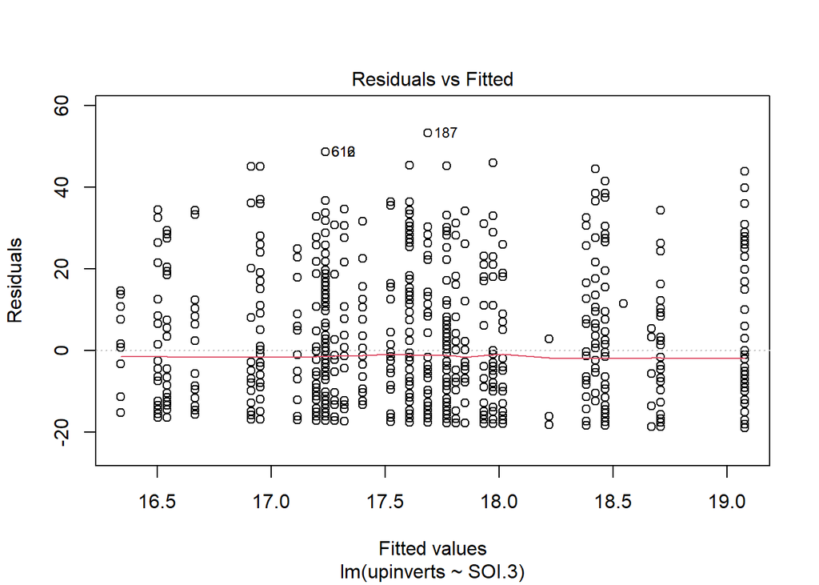

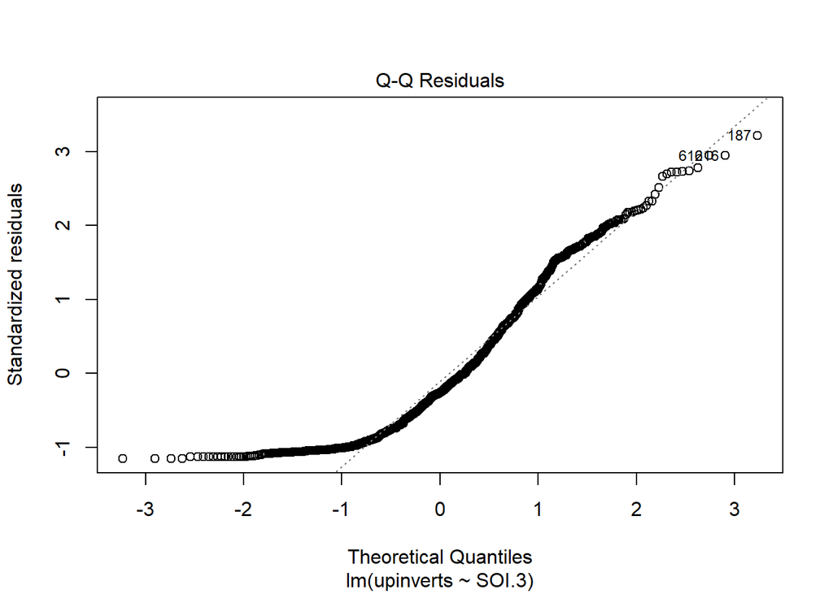

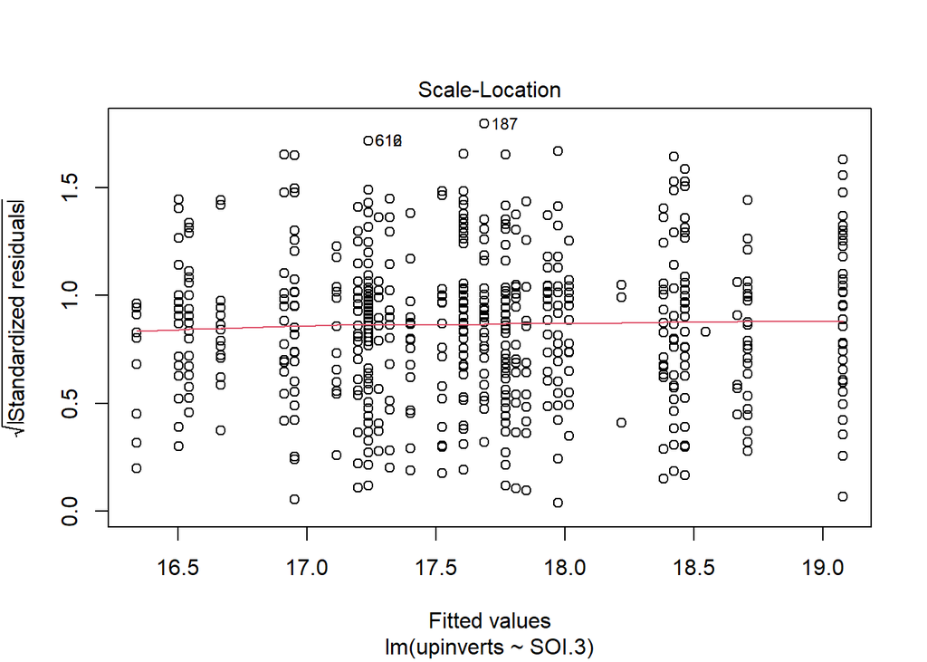

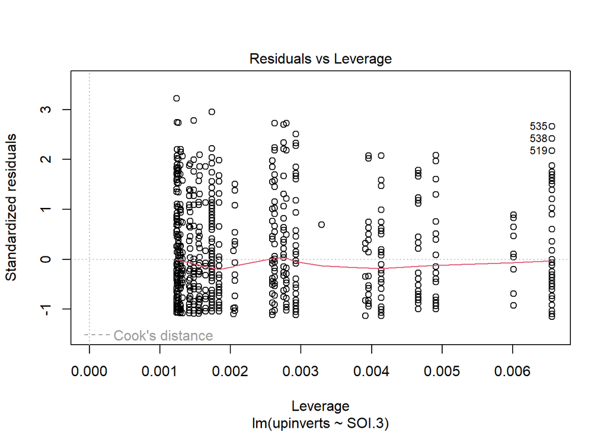

```r
plot(uiind1.3.3)
```

```r
uiind1.3.3
```

```
##
## Call:
## lm(formula = upinverts ~ SOI.3, data = masterfile)
##
## Coefficients:
## (Intercept)        SOI.3
##     17.7279       0.4088
```

```r
summary(uiind1.3.3)
```

```
##
## Call:
## lm(formula = upinverts ~ SOI.3, data = masterfile)
##
## Residuals:
##     Min      1Q  Median      3Q     Max
## -19.077 -14.665  -4.319  11.038  53.313
##
## Coefficients:
##             Estimate Std. Error t value Pr(>|t|)
## (Intercept)  17.7279     0.5838  30.365   <2e-16 ***
## SOI.3         0.4088     0.3514   1.163    0.245
## ---
## Signif. codes:  0 '***' 0.001 '**' 0.01 '*' 0.05 '.' 0.1 ' ' 1
##
## Residual standard error: 16.57 on 809 degrees of freedom
## Multiple R-squared:  0.00167,    Adjusted R-squared:  0.0004363
## F-statistic: 1.354 on 1 and 809 DF,  p-value: 0.245
```

```r
anova(uiind1.3.3)
```

```
## Analysis of Variance Table
##
## Response: upinverts
##            Df Sum Sq Mean Sq F value Pr(>F)
## SOI.3       1    372  371.51  1.3536  0.245
## Residuals 809 222044  274.47
```

```r
confint(uiind1.3.3)
```

```
##                  2.5 %    97.5 %
## (Intercept) 16.5819617 18.873917
## SOI.3       -0.2809183  1.098535
```

```
## `ci_method` must be one of "residual", "wald", "normal", "profile",
##   "boot", "uniroot", "betwithin" or "ml1". Using "wald" now.
```

#AIC - Q2, crusting, one month lag This is to answer my second question climate patterns on cover. 2) Does cover respond to ocean climate patterns (NPGO, PDO, SOI, CUTI, BEUTI)?

Save AICc results as a CSV

```r
write.csv(cindmodel1_aic, "C:/Users/Elizabeth Max/iCloudDrive/Thesis/Data/R/cindmodel1_aic.csv", row.names = TRUE)
```

Make a nice table of crusting model AIC rank results

```r
cindmodel1_table <-
  tab_df(cindmodel1_aic,  #models to table
         alternate.rows = TRUE,
         title = "AIC Model Ranking Results - all crusting species. Climate indices lagged 1 month.",
         show.footnote = TRUE)

print(cindmodel1_table)
```

Model cind1.4.1 is ranked the highest. cind1.4.1 <- lm(crusting ~ CUTI_37.1, data = masterfile) Let’s take a closer look.

Fitting and analyzing the top ranked model

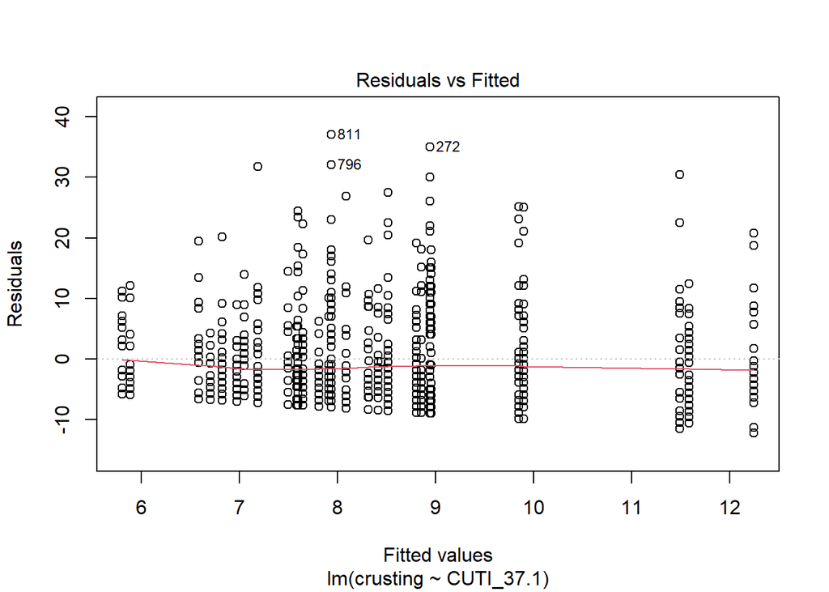

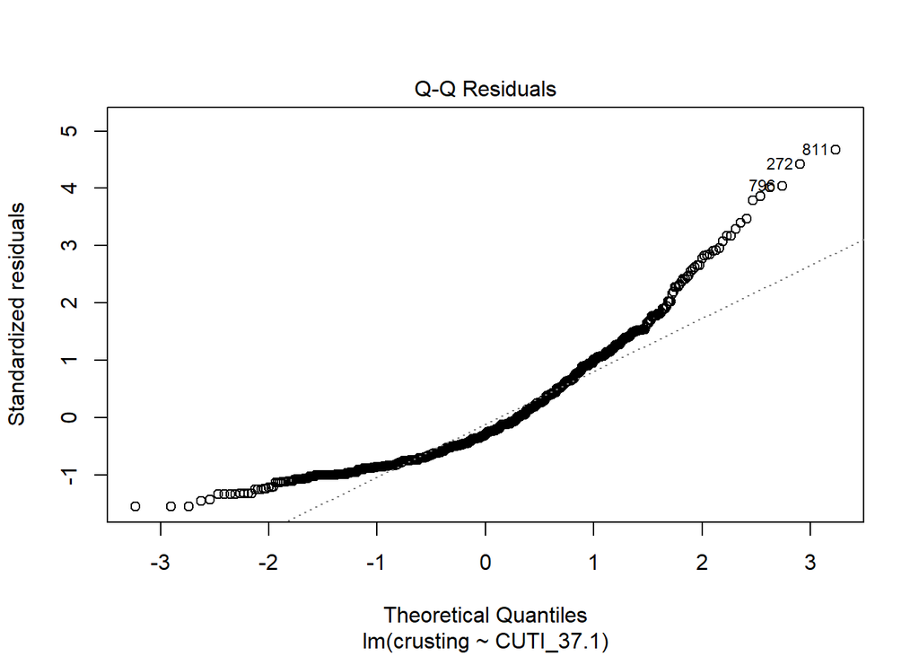

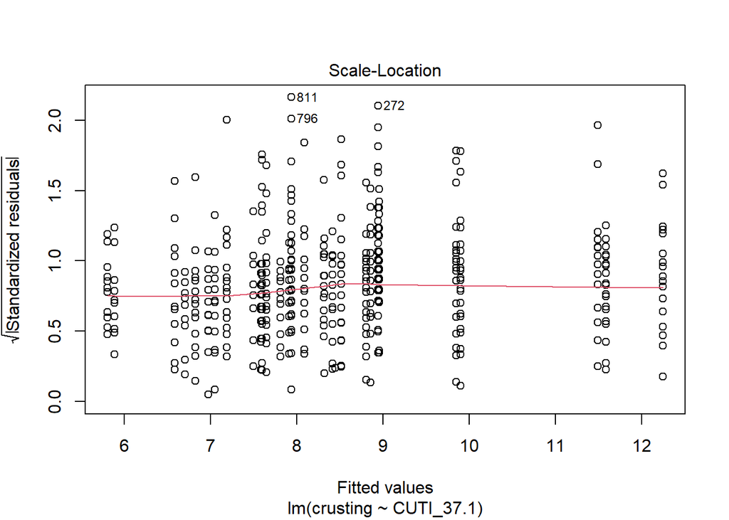

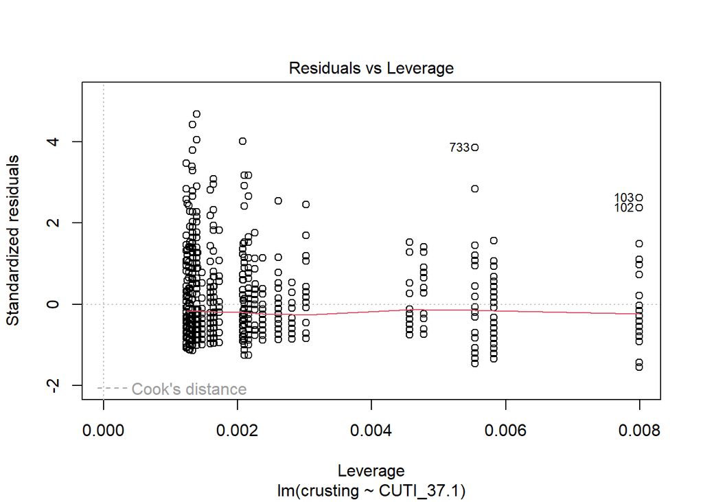

```r
plot(cind1.4.1)
```

```r
cind1.4.1
```

```
##
## Call:
## lm(formula = crusting ~ CUTI_37.1, data = masterfile)
##
## Coefficients:
## (Intercept)    CUTI_37.1
##       9.949       -4.258
```

```r
summary(cind1.4.1)
```

```
##
## Call:
## lm(formula = crusting ~ CUTI_37.1, data = masterfile)
##
## Residuals:
##     Min      1Q  Median      3Q     Max
## -12.247  -5.827  -2.247   4.049  37.059
##
## Coefficients:
##             Estimate Std. Error t value Pr(>|t|)
## (Intercept)   9.9491     0.3747  26.550  < 2e-16 ***
## CUTI_37.1    -4.2584     0.7431  -5.731 1.41e-08 ***
## ---
## Signif. codes:  0 '***' 0.001 '**' 0.01 '*' 0.05 '.' 0.1 ' ' 1
##
## Residual standard error: 7.928 on 809 degrees of freedom
## Multiple R-squared:  0.03901,    Adjusted R-squared:  0.03782
## F-statistic: 32.84 on 1 and 809 DF,  p-value: 1.413e-08
```

```r
anova(cind1.4.1)
```

```
## Analysis of Variance Table
##
## Response: crusting
##            Df Sum Sq Mean Sq F value    Pr(>F)
## CUTI_37.1   1   2064 2064.03  32.839 1.413e-08 ***
## Residuals 809  50849   62.85
## ---
## Signif. codes:  0 '***' 0.001 '**' 0.01 '*' 0.05 '.' 0.1 ' ' 1
```

```r
confint(cind1.4.1)
```

```
##                 2.5 %    97.5 %
## (Intercept)  9.213584 10.684689
## CUTI_37.1   -5.717090 -2.799768
```

```
## `ci_method` must be one of "residual", "wald", "normal", "profile",
##   "boot", "uniroot", "betwithin" or "ml1". Using "wald" now.
```

#AIC - Q2, crusting, three month lag This is to answer my second question climate patterns on cover. 2) Does cover respond to ocean climate patterns (NPGO, PDO, SOI, CUTI, BEUTI)?

Save AICc results as a CSV

```r
write.csv(cindmodel3_aic, "C:/Users/Elizabeth Max/iCloudDrive/Thesis/Data/R/cindmodel3_aic.csv", row.names = TRUE)
```

Make a nice table of crusting model AIC rank results

```r
cindmodel3_table <-
  tab_df(cindmodel3_aic,  #models to table
         alternate.rows = TRUE,
         title = "AIC Model Ranking Results - all crusting species. Climate indices lagged 3 month.",
         show.footnote = TRUE)

print(cindmodel3_table)
```

Model cind3.7.3 is ranked the highest. cind3.7.3 <- lm(crusting ~ PDO.3 + SOI.3 + CUTI_37.3, data = masterfile) Let’s take a closer look.

Fitting and analyzing the top ranked model

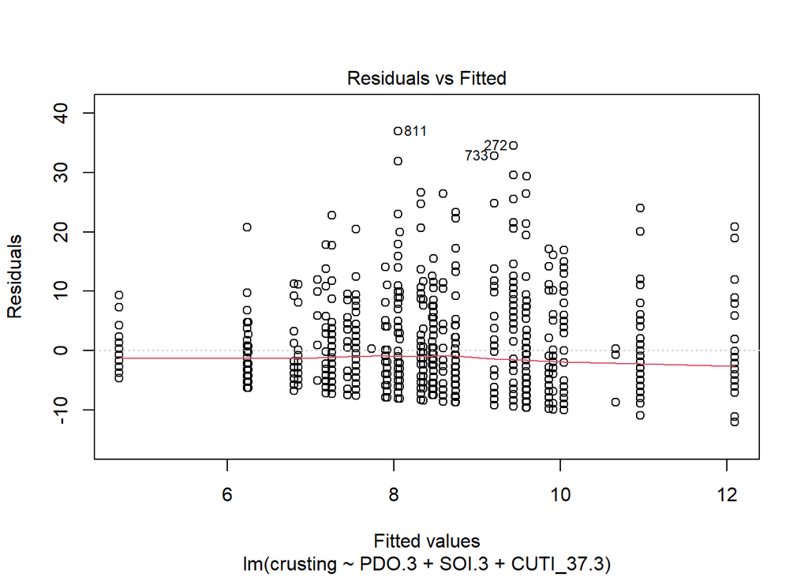

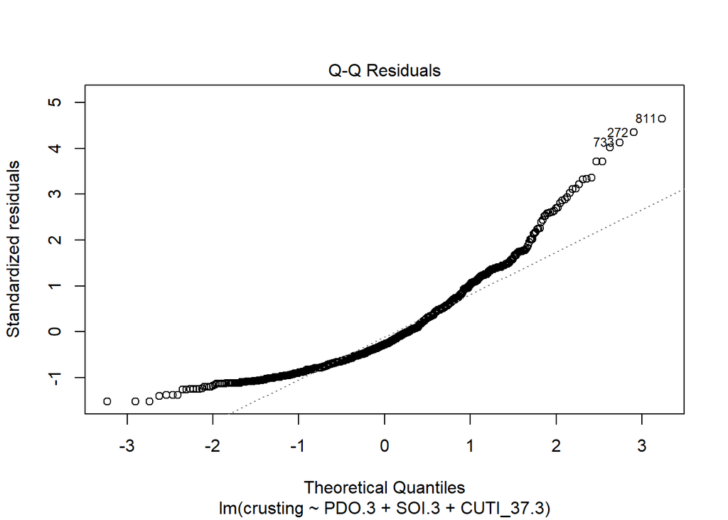

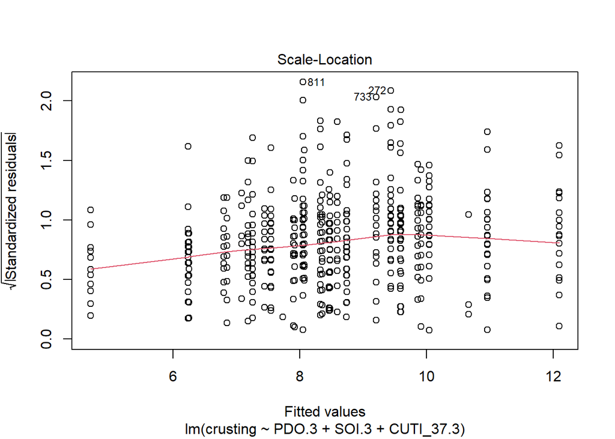

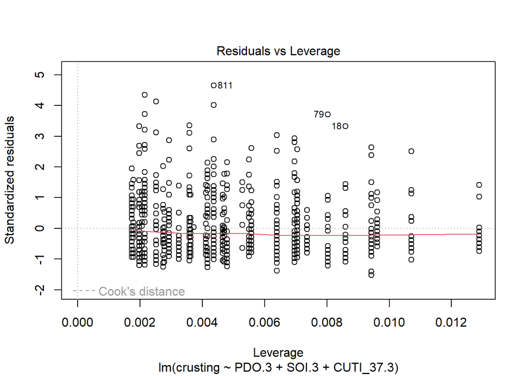

```r
plot(cind3.7.3)
```

```r
cind3.7.3
```

```
##
## Call:
## lm(formula = crusting ~ PDO.3 + SOI.3 + CUTI_37.3, data = masterfile)
##
## Coefficients:
## (Intercept)        PDO.3        SOI.3    CUTI_37.3
##     10.7102      -0.9778      -0.3985      -4.0021
```

```r
summary(cind3.7.3)
```

```
##
## Call:
## lm(formula = crusting ~ PDO.3 + SOI.3 + CUTI_37.3, data = masterfile)
##
## Residuals:
##     Min      1Q  Median      3Q     Max
## -12.091  -5.880  -2.251   4.046  36.950
##
## Coefficients:
##             Estimate Std. Error t value Pr(>|t|)
## (Intercept)  10.7102     0.6331  16.918  < 2e-16 ***
## PDO.3        -0.9778     0.2610  -3.747 0.000192 ***
## SOI.3        -0.3985     0.1892  -2.106 0.035506 *
## CUTI_37.3    -4.0021     1.0230  -3.912 9.92e-05 ***
## ---
## Signif. codes:  0 '***' 0.001 '**' 0.01 '*' 0.05 '.' 0.1 ' ' 1
##
## Residual standard error: 7.957 on 807 degrees of freedom
## Multiple R-squared:  0.03428,    Adjusted R-squared:  0.03069
## F-statistic: 9.549 on 3 and 807 DF,  p-value: 3.348e-06
```

```r
anova(cind3.7.3)
```

```
## Analysis of Variance Table
##
## Response: crusting
##            Df Sum Sq Mean Sq F value    Pr(>F)
## PDO.3       1    672  671.87  10.611  0.001171 **
## SOI.3       1    173  173.05   2.733  0.098686 .
## CUTI_37.3   1    969  969.03  15.304 9.923e-05 ***
## Residuals 807  51099   63.32
## ---
## Signif. codes:  0 '***' 0.001 '**' 0.01 '*' 0.05 '.' 0.1 ' ' 1
```

```r
confint(cind3.7.3)
```

```
##                  2.5 %      97.5 %
## (Intercept)  9.4675585 11.95288177
## PDO.3       -1.4901364 -0.46551265
## SOI.3       -0.7699314 -0.02708944
## CUTI_37.3   -6.0101405 -1.99397410
```

```
## `ci_method` must be one of "residual", "wald", "normal", "profile",
##   "boot", "uniroot", "betwithin" or "ml1". Using "wald" now.
```